# On Statistical Analysis of Survey Data TACIB Data: Opinions of Students in a Dual Language Program

# Abstract

Analyzing survey data can be challenging due to missing information, low participation, and high dimensional data. This work shows how missing data can lead to a complex structure that may adversely affect the assumptions made when the data is used to represent an underlying construct that is being modeled. This study uses Transforming Academic and Cultural Identidad through Biliteracy (TACIB) [http://tacib.weebly.com/] data, which is a series of four surveys where students rate their attitudes toward different subjects (Career, Science, Technology, Engineering and Mathematics) or C-STEM. The data points to using all responses to model a behavioral construct. After processing the data and revealing its complexities, different statistical models commonly used in survey analysis are applied.

# Introduction to Data

In diverse communities such as Southern California, educators frequently deal with students whose first language is not English or students that live in an environment where English is not the primary language. Educators are interested in measuring the impact of this environment on students’ attitude or performance.

Educators are interested in finding ways to improve the performance of students in school. Many schools adopt programs to immerse students in English or provide dual language education to maintain students’ performance while learning English. The performance of students is commonly measured by their grades or conducting interviews and observing students.

Researchers have considered investigating the implications of a dual-language immersion (DLI) program on students’ view of C-STEM subjects. The idea is that a favorable view of C-STEM is a leading indicator of success of the student. This view is supported by studies where students’ attitude is shown to have a positive correlation with academic achievement (Bakar, Tarmizi, Mahyuddin, Elias, Luan, and Ayub 2010).

In this study, the treatment group students were in the DLI program and the control group students were not enrolled in the DLI program.

# Data Complexities

Overall, 472 students participated in four surveys, each answering 25 questions (5 POV ratings for 5 subjects). However, not all 25 questions and demographic questions were answered (creating missing data), or not all students participated in all surveys (due to dropping out, or just missing the survey).

- `Pre15` is the survey that is taken at the beginning of the 2015 school year.
- `Post15` is the survey that is taken at the end of the 2015 school year.
- `Pre16` is the survey that is taken at the beginning of the 2016 school year.
- `Post16` is the survey that is taken at the end of the 2016 school year.

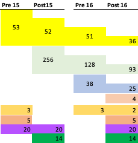

Here are some of the takeaways from the above graph:

1. The first group shows 53 participants started at the beginning of the DLI program. Continuing across the first group, only 36 participants have taken all the surveys and can be used to look for any effects of DLI program on the students over the 2 years.
2. The second group shows that 256 participants took part in the `post15` survey. Continuing across the second group, only 93 participants completed all the surveys starting with `post15`. This means that they completed `post15`, `pre16`, and `post16` surveys.
3. The fifth group shows that 3 partcipants took part in the `pre15` survey and took the `pre16` survey, but they did not take the `post15` survey. Of those 3 participants, only 2 completed the `post16` survey.

The complexities shown above suggest that care should be taken in using the data and interpreting the results. It is clear that using a complete set of surveys leads to a small dataset which may not provide much insight and combining all surveys may hide any effects that DLI might have. The following table summarizes an attempt to use larger datasets while making sure that the response(s) in the dataset are not confounded by other effects:

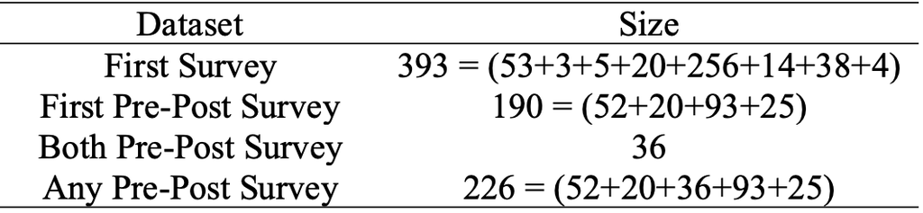

## First Survey Dataset

This includes the first survey that a student participated in. This does not provide any information about the effect of the DLI program, but it provides an opportunity to learn about the composition of the students who participated and verify if the design of the experiment did not suffer from confounding variables with the control and treatment groups. This dataset is used in exploratory data analysis.

## First Pre-Post Survey Dataset

This includes the first set of pre- and post-surveys in a school year that students completed. This means that for students who completed the entire study, only their first year surveys will be included in this dataset. This dataset includes 93 students that took part in `post15` but their exposure to the study is assumed to be minimal; this may not be a good assumption, and one can decide to remove these from the dataset.

## Both Pre-Post Survey Dataset

This includes participants who completed all four surveys in the DLI program. This dataset might be useful when looking for insights on the change of attitude over the study. This would have been the ideal dataset, but as it can be seen, the sample is too small to be useful.

## Any Pre-Post Survey Dataset

This creates the largest dataset of (pre-, post-) pairs of surveys, which is needed to measure the impact of DLI program. However, due to the inconsistencies in participation, the difference in pairs is confounded by the time students were exposed to the program (some exposed to all and others exposed partially). Nonetheless, the information can be used to compute the results with other datasets and see if the confounding effect is real.

# Exploratory Data Analysis with Principal Component Analysis

With 5 subjects and 5 POVs, there are a total of 25 different responses in the datasets. Correlation analysis shows that all responses are closely related.

The `First Survey` dataset is used in carrying out PCA. The results show that the first component explains 37.3% of the variation in the data. The second component explains 10.74% of the variation in the data (See the following graph). The fact that the first component is clearly separate from the rest of components suggests that all responses can be represented by a single construct (latent variable), which will be called *students’ attitude*.

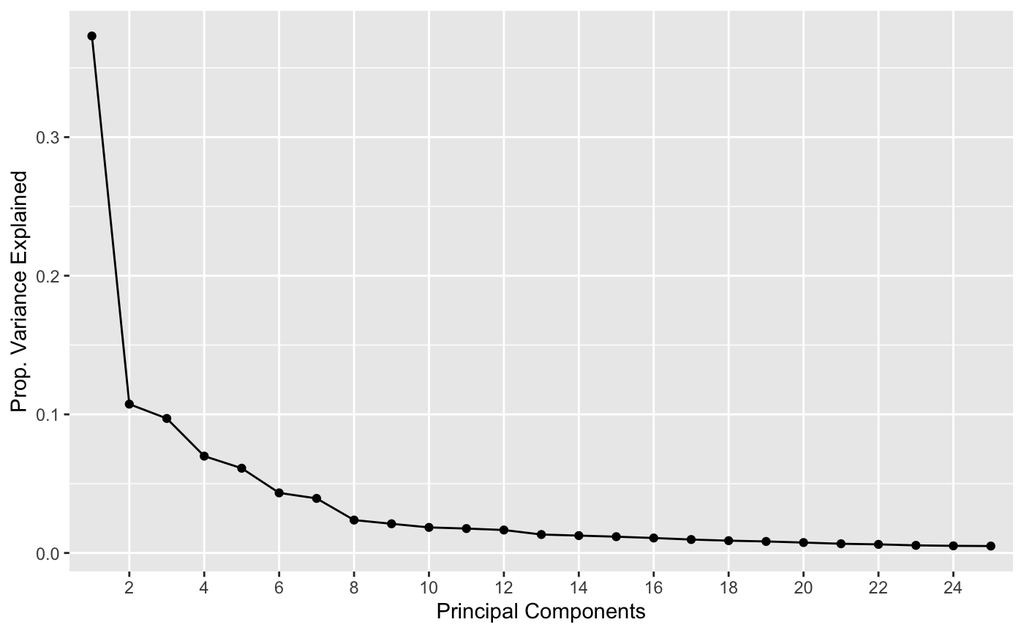

The following table lists the correlation between the responses and the first principal component.

Principal Component #1 Correlation

| Response | ResponseCorr |
| --- | --- |
| Fascinating.Career | 0.7333976 |
| Exciting.Career | 0.7254672 |
| Appealing.Career | 0.7320648 |
| MeansALot.Career | 0.6414775 |
| Interesting.Career | 0.6691247 |
| Fascinating.Eng | 0.6289067 |
| Exciting.Eng | 0.5565694 |
| Appealing.Eng | 0.5853238 |
| MeansALot.Eng | 0.6302523 |
| Interesting.Eng | 0.5892487 |
| Fascinating.Math | 0.5664001 |
| Exciting.Math | 0.5791762 |
| Appealing.Math | 0.6408604 |
| MeansALot.Math | 0.5800316 |
| Interesting.Math | 0.5482501 |
| Fascinating.Sci | 0.6256250 |
| Exciting.Sci | 0.6182404 |
| Appealing.Sci | 0.5879345 |
| MeansALot.Sci | 0.6536277 |
| Interesting.Sci | 0.6212110 |
| Fascinating.Tech | 0.5421614 |
| Exciting.Tech | 0.5082244 |
| Appealing.Tech | 0.6143884 |
| MeansALot.Tech | 0.5477230 |
| Interesting.Tech | 0.5447265 |

The correlation for each of the variables and the first principal component are all pretty similar. This supports the idea of using one latent variable as the representative response, just picking one of the responses (e.g. `Fascinating Science`), or an average of all responses (as used in Likert scale approach).

In the next step, `Fascinating Science` is selected as the representative response and the `First Survey` dataset is used to verify if the control and treatment group were not initially different.

# Initial Treatment and Control Differences

In a randomized experiment, the subjects are assigned randomly to distribute the effect of factors that are not controlled. Here, using the `First Survey`, the differences between the two groups is studied, results of which can be used as the baseline in comparing the two groups after the participation of subjects.

## Modeling First Survey using Multiple Linear Regression

As stated above, the `First Survey` dataset is used to verify if a difference between the control and treatment groups for the DLI program exists. The results of this analysis may allow for insights on students’ attitude based off their gender or treatment. The following is the formula used in the model.

$$\text{MeanLikert} \sim \text{Gf} + \text{Tr}$$

where

$$\begin{equation}
\text{MeanLikert} = \text{The mean of all responses (subjects and attitudes)}\\
\text{Gf} = \text{Gender: 1 for female and 0 for male}\\
\text{Tr} = \text{DLI program Enrollment: 1 for yes (Treatment) and 0 for no (Control)}
\end{equation}$$

The following table shows the result of this model.

Multiple Linear Regression First Survey Likert

|  | Estimate | Std.Error | t.value | p.value |
| --- | --- | --- | --- | --- |
| (Intercept) | 2.85847 | 0.09694 | 29.48616 | 0.00000 |
| Gf | 0.48376 | 0.12996 | 3.72237 | 0.00024 |
| Tr | −0.49789 | 0.14544 | −3.42333 | 0.00072 |

The estimated model is:

$$\text{MeanLikert} = 2.8584668 + (0.4837571* \text{Gf}) + (-0.4978887* \text{Tr})$$

The summary table above shows that the intercept, gender, and treatment are all significant.

When a student is female (Gf = 1), using this model, the student would have an increase of 0.4837571 in mean Likert than if they were a male. This means that, for this model, before starting the DLI program, a female student would more likely have a worse attitude than a male student.

When a student is part of the DLI program (Tr = 1), the student would have a decrease of -0.4978887 in mean Likert than if they were not part of the DLI program. This means that, for this model, before starting the DLI program, students who are enrolling in the DLI program would have a better attitude than students that are not enrolling in the DLI program.

# Measuring DLI Effect

In the model above, it was found that there is a difference between the treatment and control groups. Now, the rest of the analysis uses the `First Pre-Post` dataset to see in what ways the DLI program might have had an effect on the participating students.

## Multinomial Logistic

This model treats the response as a categorical response and is predicted by gender, treatment, and pre- ratings from 1, 2, … 7. Fascinating Science is chosen to represent the attitude.

The model formula is:

$$\text{Fascinating Sci Post} \sim \text{Fascinating Sci Pre} + \text{Gf} + \text{Tr}$$

where

$$\begin{equation}
\text{Fascinating Sci Post} = \text{Fascinating Science post- rating}\\
\text{Fascinating Sci Pre} = \text{Fascinating Science pre- rating}\\
\text{Gf} = \text{Gender: 1 for female and 0 for male}\\
\text{Tr} = \text{DLI program Enrollment: 1 for yes (Treatment) and 0 for no (Control)}
\end{equation}$$

The following table is the output from this model. These are the coefficients for each variable for the log of odds equations.

Multinomial Logistic Regression First Year Coefficients

|  | Intercept | Gf | Tr | Fascinating.Sci.pre |
| --- | --- | --- | --- | --- |
| 2 | -0.8189309 | -0.41610721 | -1.0438951 | 0.3292464 |
| 3 | -1.4974643 | -0.10396028 | 0.1898457 | 0.5035956 |
| 4 | -2.9990173 | 0.66957114 | -0.2300308 | 0.8471999 |
| 5 | -4.1408333 | -0.14992372 | -0.5422326 | 0.8934553 |
| 6 | -5.0853321 | 0.07180329 | 0.1897586 | 1.0959682 |
| 7 | -5.9997418 | 1.41617309 | 0.7018533 | 0.9499048 |

The following table lists the p-values for each coefficient from the previous table.

Multinomial Logistic Regression First Year P-Values

|  | Intercept | Gf | Tr | Fascinating.Sci.pre |
| --- | --- | --- | --- | --- |
| 2 | 0.14367 | 0.41138 | 0.13905 | 0.09350 |
| 3 | 0.00786 | 0.82895 | 0.72412 | 0.00627 |
| 4 | 0.00001 | 0.20472 | 0.71508 | 0.00001 |
| 5 | 0.00019 | 0.86063 | 0.64214 | 0.00130 |
| 6 | 0.00003 | 0.93058 | 0.84245 | 0.00007 |
| 7 | 0.00017 | 0.23296 | 0.49678 | 0.00345 |

The variables for each row form the log of odds for each level. That is, the probability of ratings 2-7 divided by the probability of rating 1.

For example, the log of odds of the probability of rating=2 and the probability of rating=1 is shown below.

$$\text{ln}\left(\dfrac{P(X = 2)}{P(X = 1)}\right) = -0.8189309 + (-0.4161072* \text{Gf}) + (-1.0438951* \text{Tr}) + (0.3292464* \text{Rating})$$

After exponentiating, the equation is as follows:

$$\dfrac{P(X = 2)}{P(X = 1)} = e^{-0.8189309 + (-0.4161072* \text{Gf}) + (-1.0438951* \text{Tr}) + (0.3292464* \text{Rating})}$$

The equation can be simplified to:

$$\dfrac{P(X = 2)}{P(X = 1)} = C$$

where

$$C = e^{-0.8189309 + (-0.4161072* \text{Gf}) + (-1.0438951* \text{Tr}) + (0.3292464* \text{Rating})}$$

When C > 1, the probability of the response being 2 is greater than the probability of the response being 1. Likewise, if C < 1, the probability of the response being 1 is greater than the probability of the response being 2.

Interpreting the coefficients, if a student is female (Gf = 1), then the log odds will decrease by -0.4161072. If a student is in the DLI program (Tr = 1), then the log odds will decrease by -1.0438951. However, the values for gender and treatment are not significant.

All the values for the intercepts and ratings for Fascinating Sci at the start of the school year are significant except for the log odds of X = 2.

For every 1 increase in the rating, there is a 0.3292464 increase in the log odds. A student who rates Fascinating Sci at the beginning with 1 will have a higher probability of rating Fascinating Sci at the end with 1. This probability decreases as the student selects 2, 3, etc.

### Prediction Error Analysis for Multinomial Logistic

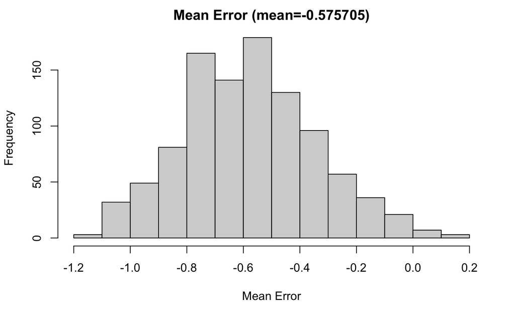

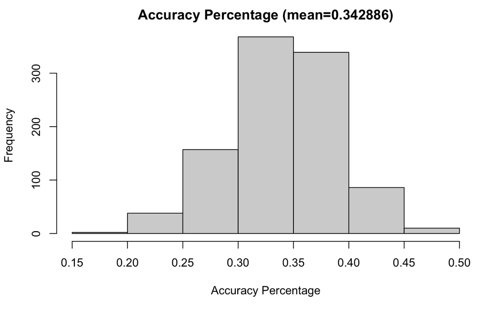

For the simulations and prediction error analysis, the seed is set to 33 to be able to reproduce the numbers.

For the mean error histogram, the mean error falls is centered at -0.5757045. Most of the data lies less than 0, which means that the model is underestimating the ratings of Fascinating Sci at the end of the school year. The more ideal model will have the mean error centered at 0.

For the accuracy percentage histogram, the accuracy percentage is centered at 0.3428864.

### Assumption Analysis for Multinomial Logistic

When running multinomial logistic regression, the variables are treated as nominal i.e there is no ordering of the ratings and the distance between each rating is the same. However, this might not be true as the distance from 1 and 2 might not be the same as the distance from 6 to 7.

There must not be multicollinearity in the model. This means that the independent variables must not have a linear relationship between each other. When running a linear model between only gender and treatment, there is no significant slope i.e there is no linear relationship between gender and treatment. Similarly, there is no linear relationship between Fascinating Science and gender or Fascinating Science and treatment.

Looking at the correlation between the independent variables such as ratings and gender, there is no linear correlation.

In terms of the outlier assumption, there are no obvious outliers with the predictors of ratings, gender, and treatment. Due to the nature of the survey data, the responses from the beginning of the year and the end of the year are reasonable across the range of the ratings (1-7).

## Ordinal Logistic Regression

Another way to look at categorical responses with the TACIB data is to predict the difference in response using gender or treatment. The response here is ordinal i.e the numbers are ordered and distance is not necessarily the same between each response.

The formula for this model is:

$$\text{FascSciDiff} \sim \text{Gf} + \text{Tr}$$
$$\begin{equation}
\text{FascSciDiff} = \text{Fascinating Sci Post} - \text{Fascinating Sci Pre}\\
\text{Gf} = \text{Gender: 1 for female and 0 for male}\\
\text{Tr} = \text{DLI program Enrollment: 1 for yes (Treatment) and 0 for no (Control)}
\end{equation}$$

The following table is a summary of the model.

Ordinal Logistic Regression First Year

|  | Value | Std.Error | t.value | p.value |
| --- | --- | --- | --- | --- |
| Gf | 0.10170 | 0.28642 | 0.35506 | 0.72255 |
| Tr | 0.24112 | 0.33024 | 0.73014 | 0.46531 |
| -5\|-4 | −4.23281 | 0.72729 | −5.81996 | 0.00000 |
| -4\|-3 | −3.52567 | 0.52836 | −6.67286 | 0.00000 |
| -3\|-2 | −2.37002 | 0.33712 | −7.03014 | 0.00000 |
| -2\|-1 | −1.49157 | 0.26418 | −5.64596 | 0.00000 |
| -1\|0 | −0.54003 | 0.22928 | −2.35532 | 0.01851 |
| 0\|1 | 0.66959 | 0.23139 | 2.89379 | 0.00381 |
| 1\|2 | 1.79879 | 0.27451 | 6.55280 | 0.00000 |
| 2\|3 | 3.15183 | 0.41989 | 7.50635 | 0.00000 |
| 3\|4 | 4.02664 | 0.60608 | 6.64374 | 0.00000 |
| 4\|6 | 5.13910 | 1.01700 | 5.05319 | 0.00000 |

From the table above, looking at the first column, the rows below `Tr` represent the output for each level. The values for each level combined with the values for `Gf` and `Tr` form the log of odds equations. The probabilities in this model are cumulative.

The corresponding equation for the log of odds at level -3 | -2 is:

$$\text{ln}\left(\dfrac{P(X\leq-3)}{P(X>-3)}\right) = -2.3700206 - (0.1016962 * \text{Gf}) - (0.241121 * \text{Tr})$$

After exponentiating both sides of the equation, the equation looks like:

$$\dfrac{P(X\leq-3)}{P(X>-3)} = e^{-2.3700206 - (0.1016962 * \text{Gf}) - (0.241121 * \text{Tr})}$$

When a student is female (Gf = 1), then the log odds will decrease by 0.1016962 i.e the log odds is smaller than if the student was male.

When a student is in a DLI program (Tr = 1), then the log odds will decrease by 0.241121 i.e the log odds is smaller than if the student was not enrolled in DLI.

An important note is that gender and treatment are not significant. The logit coefficients all end up being significant though.

### Prediction Error Analysis for Ordinal Logistic Regression

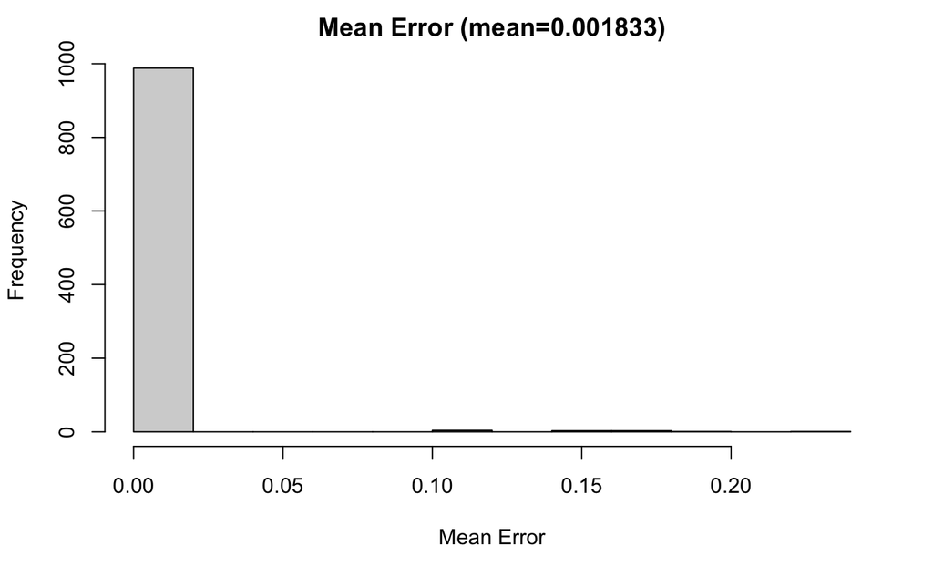

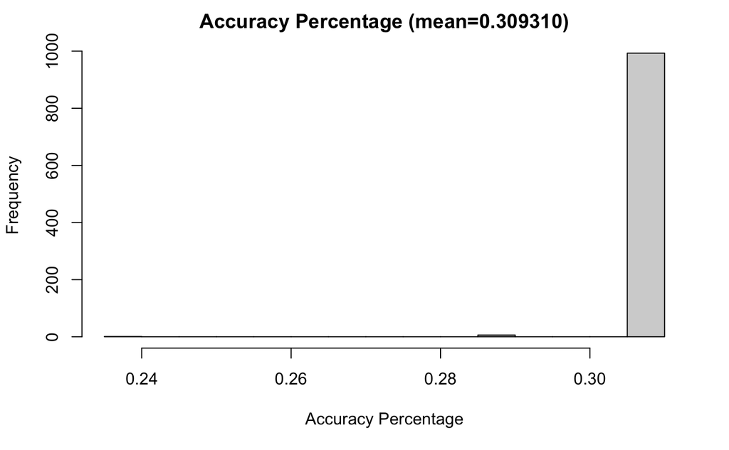

For the simulations and prediction error analysis, the seed is set to 33 to be able to reproduce the numbers.

The center for the mean error is 0.0018333.

When looking at the model’s prediction over the simulations, one thing that stands out is that the model predicts 0 for most of the test data. This is a problem because the model is doing a bad job at predicting the responses. The accuracy percentage has a mean of 0.3093095. This is probably from chance by selecting 0 most of the time.

The model might not have enough data to draw any conclusions from the results. Some of the levels have very few data points, which is problematic for the model.

### Assumption Analysis for Ordinal Logistic Regression

Using the survey responses as Likert items is already inherently ordinal and meets the criteria for the response variable being at the ordinal level.

Another assumption that must be checked is that independent variables cannot be treated as ordinal. This is also met because the independent variables gender and treatment are categorical and binary.

Multicollinearity analysis has already been done with multiple linear regression. This assumption is also met.

```
--------------------------------------------
Test for    X2  df  probability
--------------------------------------------
Omnibus     17.39   18  0.5
Gf      9.37    9   0.4
Tr      7.82    9   0.55
--------------------------------------------

H0: Parallel Regression Assumption holds
```

When running ordinal logistic regression, an assumption that must be met is the odds ratios across all the categories must be the same. Looking at the above output for the brant test, this assumption is also met.

Now, the modeling that follows takes a look at the response as numerical.

## Multiple Linear Regression

Logistic regression models had more complexity with several equations and dealt with the log of odds. On the other hand, the multiple linear regression model is more straightforward in predicting a numerical response.

### Mean Likert

As mentioned in exploratory data analysis, students’ attitude can be represented using the Likert scale and taking the average of all responses. This model predicts the mean Likert post responses using the mean Likert pre responses, gender, and treatment.

The following formula makes use of the means of all the ratings:

$$\text{LikertPost} \sim \text{LikertPre} + \text{Gf} + \text{Tr}$$

where

$$\begin{equation}
\text{LikertPost} = \text{The mean of all post- responses (subjects and attitudes)}\\
\text{LikertPre} = \text{The mean of all pre- responses (subjects and attitudes)}\\
\text{Gf} = \text{Gender: 1 for female and 0 for male}\\
\text{Tr} = \text{DLI program Enrollment: 1 for yes (Treatment) and 0 for no (Control)}
\end{equation}$$

The following table is a summary of the model:

Multiple Linear Regression First Year Likert

|  | Estimate | Std.Error | t.value | p.value |
| --- | --- | --- | --- | --- |
| (Intercept) | 1.07697 | 0.21832 | 4.93310 | 0.00000 |
| LikertPre | 0.61757 | 0.06736 | 9.16838 | 0.00000 |
| Gf | 0.20367 | 0.15604 | 1.30519 | 0.19495 |
| Tr | −0.17033 | 0.17652 | −0.96496 | 0.33699 |

From the above table, the intercept and LikertPre coefficients are significant while the Gf and Tr coefficients are not significant. The model formula is:

$$\text{LikertPost} = 1.0769737 + (0.6175732* \text{LikertPre}) + (0.2036685* \text{Gf}) + (-0.1703347* \text{Tr})$$

For every 1 increase in the mean with LikertPre, there is an increase of 0.6175732 for LikertPost, keeping everything else constant. If the student is a female, there is an increase of 0.2036685 for LikertPost, keeping everything else constant. If the student is part of the DLI program, there is a decrease of -0.1703347 for LikertPost.

Looking at the equation and ignoring the coefficients for Gf and Tr, the line Post=1.076974 + 0.617573*Pre and the line Post = Pre are graphed and compared.

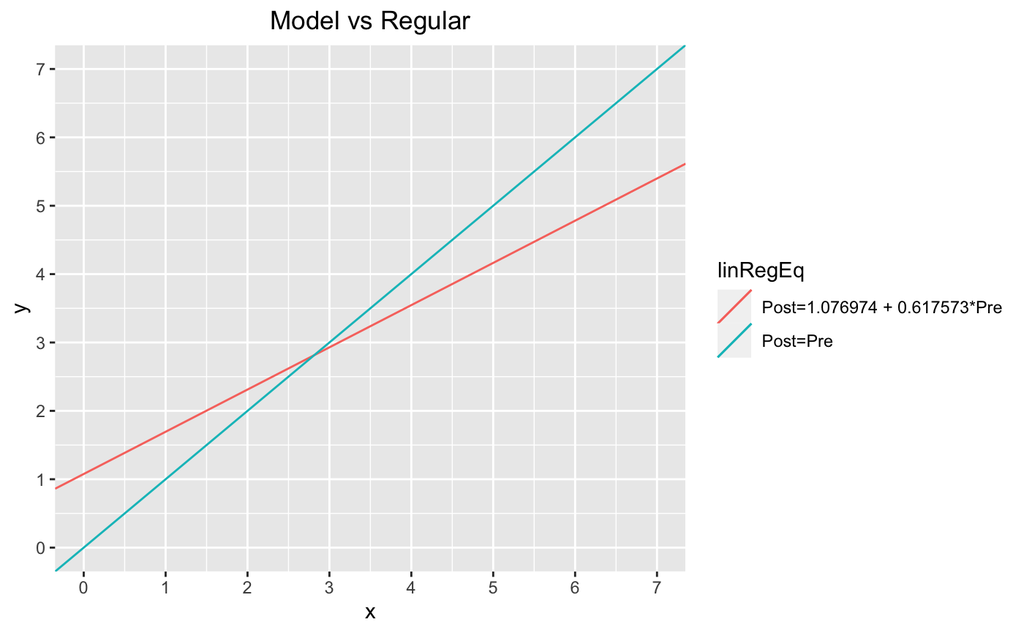

One thing that stands out in the graph is that for students with attitudes less than around 3, their ratings towards the subjects got worse. For students with attitudes greater than around 3, their ratings got better.

Although the treatment coefficient came out to be insignificant, it is worth noting that if a student was apart of the DLI program, the model states that their mean rating at the end of the year was slightly better or more positive than a student that was not part of the DLI program.

#### Prediction Error Analysis for Mean Likert

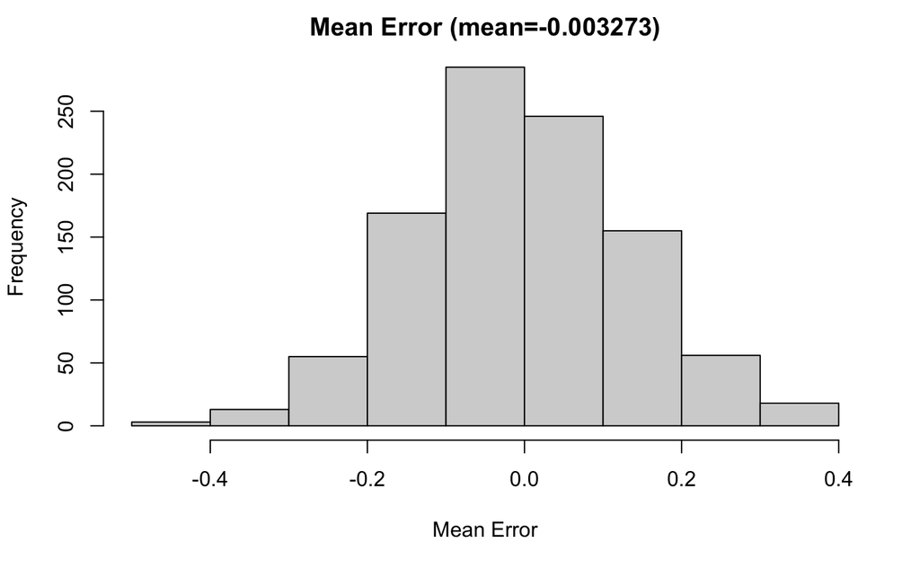

For the simulations and prediction error analysis, the seed is set to 33 to be able to reproduce the numbers.

Looking at the mean error histogram, the data is centered at -0.0032728.

Just by looking at this model, the model is quite better than the logistic model in that the mean error is centered around 0. This means that the train model is estimating the test subset pretty well.

The following model also uses the mean Likert scale but instead predicts the difference in mean Likert for post surveys minus pre surveys.

### Difference Mean Likert

The model examines if there is any significance with gender and enrollment in DLI to predict a difference in rating. A negative LikertDiff would indicate that a student’s attitude got better or is more positive than before while a positive value would indicate a student’s attitude got worse or is more negative.

The following is the formula for the model:

$$\text{LikertDiff} \sim \text{Gf} + \text{Tr}$$

where

$$\begin{equation}
\text{LikertDiff} = \text{LikertPost} - \text{LikertPre}\\
\text{Gf} = \text{Gender: 1 for female and 0 for male}\\
\text{Tr} = \text{DLI program Enrollment: 1 for yes (Treatment) and 0 for no (Control)}
\end{equation}$$

The following table is the summary of the model:

Multiple Linear Regression First Year Likert Diff

|  | Estimate | Std.Error | t.value | p.value |
| --- | --- | --- | --- | --- |
| (Intercept) | 0.00637 | 0.12649 | 0.05033 | 0.95996 |
| Gf | −0.01952 | 0.17363 | −0.11243 | 0.91071 |
| Tr | 0.10894 | 0.19492 | 0.55890 | 0.57751 |

The above table provides a summary of the difference in mean Likert. An equation can be formed using the values under the `Estimate` column:

$$\text{LikertDiff} = 0.0063658 + (-0.0195221* \text{Gf}) + (0.1089419* \text{Tr})$$

When a student is female (Gf = 1), the mean difference decreases by -0.0195221. When a student is part of the DLI program, the mean difference increases by 0.1089419.

Interestingly enough, when a student is female, their attitude was better than if a student was male just through using this model. If a student was in the DLI program, their attitude got worse.

However, looking at the p-values, the model has no significant intercept or variables. This means that the intercept and slopes for Gf and Tr may not necessary for the model to predict the Likert difference and that the results may just be by chance.

#### Prediction Error Analysis for Difference Mean Likert

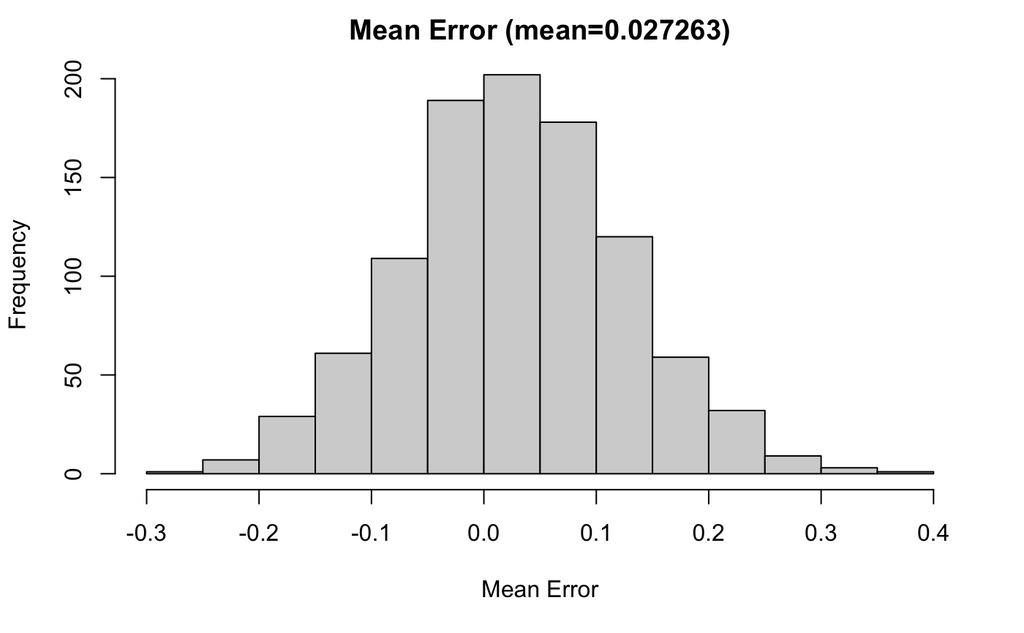

For the simulations and prediction error analysis, the seed is set to 33 to be able to reproduce the numbers.

The model looks good when it comes to looking at mean error. The mean error is centered around 0.0272634.

### Assumption Analysis for Multiple Linear Regression

In deciding to use linear regression, it is important to make sure that the variables have a linear relationship. This can be checked by plotting the response variable against the residuals of the model.

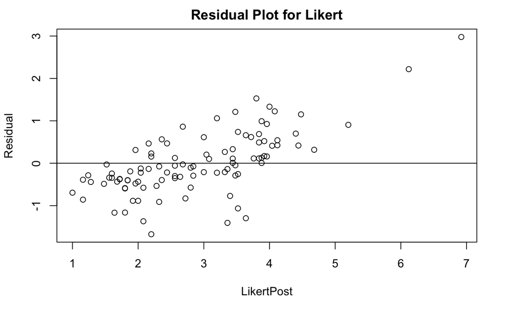

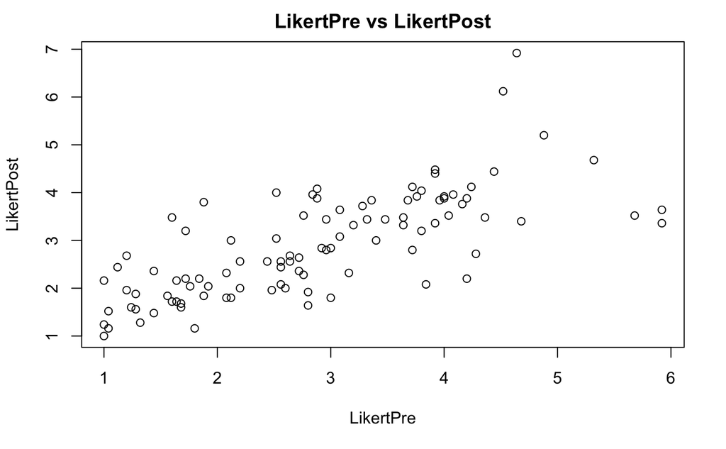

The graph above is a plot of the response variable LikertPost against the independent variable LikertPre. There is a linear relationship by drawing a rough line. There are outliers in the plot, but there are not many.

Next, there must be no colinearity or dependence between the predictor variables. The chi square test of independence is used to look Gf and Tr.

```
    Pearson's Chi-squared test with Yates' continuity correction

data:  contTable
X-squared = 0.23824, df = 1, p-value = 0.6255
```

The above output shows the summary of the chi-square test with a p-value of 0.6254823. It is found that the p-value is not significant, meaning there is not enough evidence to conclude that the two variables are dependent. This means that the variables are independent, and so this assumption is met.

Linear regression models are also used to test for linear relationships between LikertPre vs Gf and LikertPre vs Tr.

```
Call:
lm(formula = Tr ~ LikertPre, data = tacib)

Residuals:
    Min      1Q  Median      3Q     Max
-0.4477 -0.2929 -0.1874  0.5561  1.0196

Coefficients:
            Estimate Std. Error t value Pr(>|t|)
(Intercept)  0.54267    0.11317   4.795 5.81e-06 ***
LikertPre   -0.09498    0.03641  -2.608   0.0105 *
---
Signif. codes:  0 ‘***’ 0.001 ‘**’ 0.01 ‘*’ 0.05 ‘.’ 0.1 ‘ ’ 1

Residual standard error: 0.4337 on 98 degrees of freedom
Multiple R-squared:  0.06492,   Adjusted R-squared:  0.05538
F-statistic: 6.804 on 1 and 98 DF,  p-value: 0.01052
```

The above output is a summary of the linear model of treatment versus LikertPre.

```
Call:
lm(formula = Gf ~ LikertPre, data = tacib)

Residuals:
    Min      1Q  Median      3Q     Max
-0.7243 -0.4402 -0.2878  0.5015  0.7047

Coefficients:
            Estimate Std. Error t value Pr(>|t|)
(Intercept)  0.18993    0.12802   1.484   0.1411
LikertPre    0.09407    0.04119   2.284   0.0245 *
---
Signif. codes:  0 ‘***’ 0.001 ‘**’ 0.01 ‘*’ 0.05 ‘.’ 0.1 ‘ ’ 1

Residual standard error: 0.4906 on 98 degrees of freedom
Multiple R-squared:  0.05053,   Adjusted R-squared:  0.04085
F-statistic: 5.216 on 1 and 98 DF,  p-value: 0.02454
```

The above output is a summary of the linear model of gender versus LikertPre.

The slopes are significant in both models. This may raise an issue because there is colinearity between the predictor variables. As a result, the conclusions made using these linear regression models may or may not be correct.

Another assumption that should be checked is data normality. With multiple variables, this means multivariate normality must be checked. One way to test this is by using the Henze-Zirkler’s test. The results of the test show that the data do not follow a multivariate normal distribution. This might also be problematic.

## Random Forest Algorithm

Random forests allow for both linear and non-linear predictions and as well as for the use of regression or classification. The use of this algorithm could bring new insights beyond the linear and logistic regression models. The only downside is that random forests are more of a black box and less interpretable than the previous models.

### Regression

The modeling for the random forest regression algorithm will also represent students’ attitude using the mean of responses. The following graph is a plot of the error against the number of trees used in the random forest algorithm.

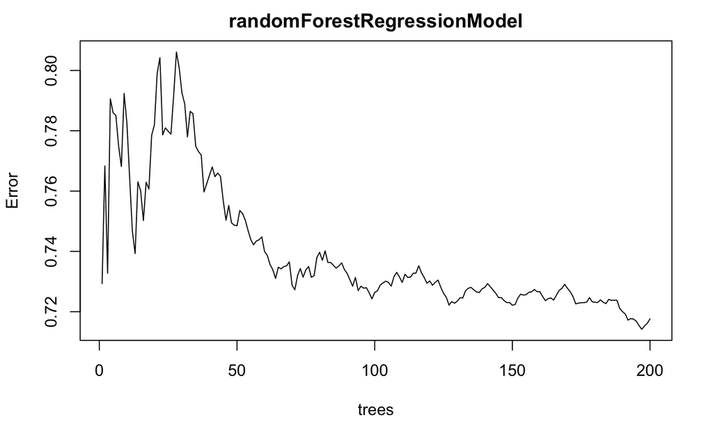

Random forest parameters can be configured in order to deal with overfitting and optimization for error. By around 200 trees, the error is stabilizing and has little change in error. This will be the number of trees to use for the model and simulation for testing the prediction error.

The following is the output summary from the algorithm.

```
Call:
 randomForest(formula = LikertPost ~ LikertPre + Gf + Tr, data = tacib,      proximity = TRUE, replace = TRUE, ntree = 200)
               Type of random forest: regression
                     Number of trees: 200
No. of variables tried at each split: 1

          Mean of squared residuals: 0.7176375
                    % Var explained: 38.07
          IncNodePurity
LikertPre     41.914599
Gf             4.979360
Tr             5.576897
```

Since the random forest algorithm is random, the seed is set to 33 to be able to reproduce the numbers.

Taking a look at the output from the random forest model and its importance, the mean of squared residuals is 0.7176375 and the percentage of variance explained is 38.0720322%

`IncNodePurity` measures the difference between the mean square error of the random permutation of the given independent variable and the mean square error of the original model. This means that a higher, positive increase indicates more of an importance in the context of the errors in the random forest algorithm. The mean of the beginning of the year ratings is a lot more significant in predicting the response than gender or treatment.

#### Prediction Error Analysis for Regression

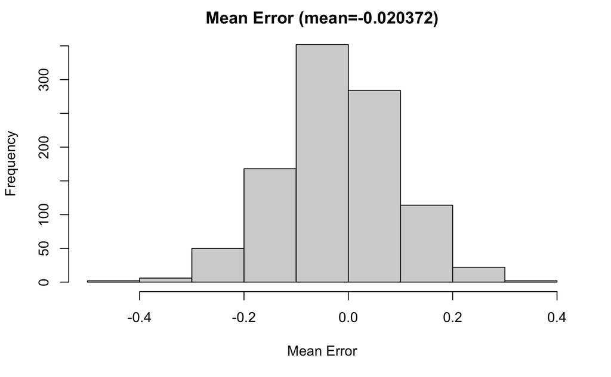

For the simulations and prediction error analysis, the seed is set to 33 to be able to reproduce the numbers.

The center of the mean error is -0.0203724. This is very similar to the linear regression model. The algorithm does not give much inference interpretation as the linear regression model.

### Classification

The modeling for the random forest classification algorithm will also represent students’ attitude using Fascinating Science. The following graph is a plot of the error for each rating against the number of trees used in the random forest algorithm.

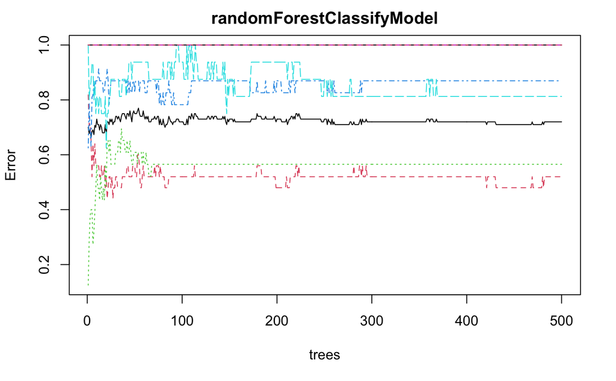

```
Call:
 randomForest(formula = Fascinating.Sci.post ~ Fascinating.Sci.pre +      Gf + Tr, data = tacib, proximity = TRUE, replace = TRUE,      ntrees = 200)
               Type of random forest: classification
                     Number of trees: 500
No. of variables tried at each split: 1

        OOB estimate of  error rate: 72%
Confusion matrix:
   1  2 3 4 5 6 7 class.error
1 12  9 3 1 0 0 0   0.5200000
2  8 10 1 4 0 0 0   0.5652174
3  6  9 3 5 0 0 0   0.8695652
4  2  9 2 3 0 0 0   0.8125000
5  0  3 1 1 0 0 0   1.0000000
6  1  2 1 0 0 0 0   1.0000000
7  2  0 1 1 0 0 0   1.0000000
                    MeanDecreaseGini
Fascinating.Sci.pre         8.144903
Gf                          2.224880
Tr                          2.498401
```

Since the random forest algorithm is random, the seed is set to 33 to be able to reproduce the numbers.

Looking at the output above, the out of bag estimate of error rate is 72%.

The confusion matrix provides information about the classification error for each factor (1, 2, …, 7). Something important to pay attention to is the 100% classification error for ratings 5, 6, and 7. This might be because there aren’t as many observations for these ratings.

The random forest classification provides numbers for the mean decrease gini. An important variable will have a higher mean gini decrease. Like random forest regression, the rating has more of an impact in the random forest than gender and treatment.

#### Prediction Error Analysis for Classification

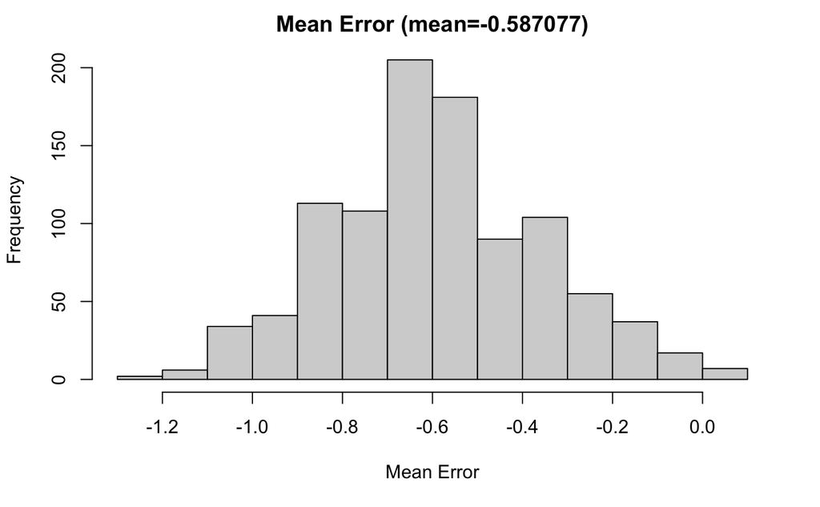

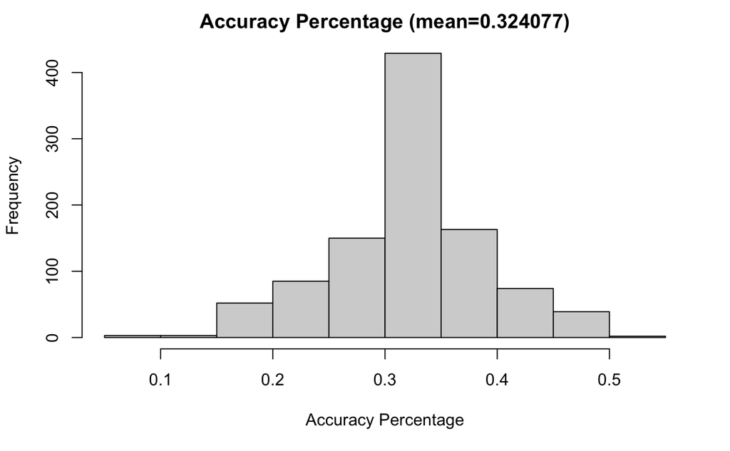

For the simulations and prediction error analysis, the seed is set to 33 to be able to reproduce the numbers.

The center for the mean error is -0.5870769 and the center for the accuracy percentage is 0.3240769.

Right off the bat, the error histograms are worse than the random forest regression. This is analogous to the error comparisons between linear and logistic regression.

### Assumption Analysis for Random Forest Algorithm

Random forests are robust to outliers and can deal with both linear and non-linear situations. Thus, there is no need to test for assumptions.

# Comparing Models

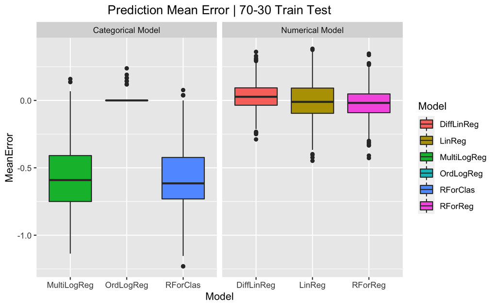

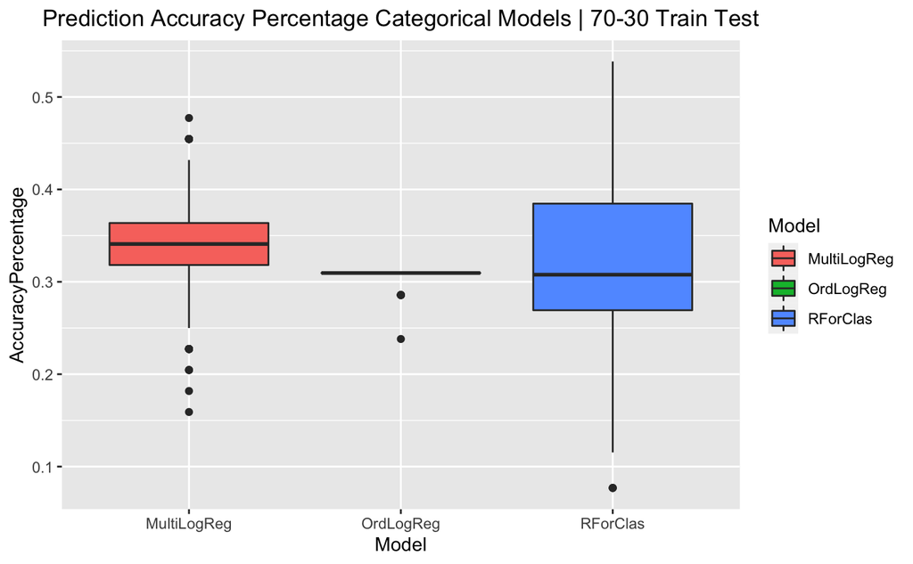

For the categorical models, the mean error range for the random forest algorithm is about the same as multinomial logistic regression. However, the random forest algorithm isn’t as interpretable as the other models. Both multinomial and random forest mean error prediction are centered almost near -0.5. This means that these models are predicting students’ attitude are better than their actual attitudes. With ordinal logistic regression, the model is not a great fit as it mostly predicts the same number.

For the numerical models, the models mean errors are centered near 0. This is better than the categorical models. This means that the model was quite accurate in predicting students’ mean responses. Looking closely at the box plots, linear regression’s mean error is closer to 0 than the other two models. However, the range of the linear regression model is slightly wider than the other models as well - there is a little bit more variability in the predictions.

Akaike Information Criterion (AIC) for Models

|  | MultiLogRegress | OrdLogRegress | LinRegress | DiffLinRegress |
| --- | --- | --- | --- | --- |
| 1 | 527.25909 | 609.45062 | 232.36003 | 259.31036 |

Another way of comparing models is by comparing Akaike Information Criterion (AIC). This is an estimator for prediction error; however, the absolute values from AIC should not be used to describe models. Another important thing to note is that dataset size is part of the formula. Models with different dataset sizes should not be compared using AIC. The model comparisons will be within the groups for categorical and numerical.

The model with the lower AIC is better and can lead to the conclusion that the model is a better fit. Note that the random forest algorithm inherently is more complex with the number of trees and splits. AIC is not useful for these models and is not included in the AIC analysis.

For categorical models, multinomial logistic regression has a lower, better AIC score than ordinal logistic regression.

For numerical models, linear regression has a lower, better AIC score than linear regression for the difference in Likert means.

# Conclusion

The original goal of the study was to uncover whether DLI programs are effective in improving students’ attitude towards C-STEM subjects. However, the survey study raises two issues that need to be addressed: a lack of control on the distribution of subjects and a lack of control on when participants enter and exit the study. The former is problematic because it can lead to uneven distribution of subjects, introducing a confounding variable and making the comparison biased. In the latter, the exposure time could become a confounding variable.

TACIB data, which is high dimensional survey data, is used to show how the uneven distribution and exposure time can be identified. The inconsistent patterns of when subjects took the surveys and the different subsets of the data were used to identify potential uneven distributions and separate exposure time effects.

The `First Survey` subset was modeled using linear regression and confirmed that the control and treatment groups had an uneven distribution in terms of students’ attitude towards C-STEM (the treatment group had a better attitude towards these subjects). The model also showed that female students had worse attitudes towards these subjects. It should be noted that part of the data was for students who might have been exposed to the program but their first survey was a post survey. This means that more analysis is needed to make sure that the results mentioned here are not confounded by the exposure time.

The `First Pre-Post` subset was used to measure the impact of DLI, but there was no significant effect found. However, in light of the uneven distribution of initial attitudes in the control and treatment groups, the result may not be accurate. The result also might be adversely affected by exposure time as a confounding variable.

In summary, this example shows that finding significance or the absence of it when the survey data includes the mentioned inconsistencies may be impacted by the uneven distribution and exposure time confounding variables.

# Future Work

The work done in this study showed how to identify inconsistencies that may contribute to exposure time as a confounding variable and how to use subsets to identify potential uneven distributions, which also can create a confounding variable.

For survey data where there is no luxury of correcting inconsistencies, finding procedures that can account for and separate the effects of uneven distributions is valuable in making correct inferences from existing datasets.

In particular, for TACIB data, having a more favorable attitude towards C-STEM in the treatment group might be masking the benefits that a DLI program might offer disadvantaged students.

When more procedures are run to account for the mentioned confounding variables, running the models on the other subsets may be useful in comparing results. The inclusion of additional TACIB data such as students’ ethnicity or parent’s interest may also give further insight on the effects of DLI.

The above goals might require looking at more statistical models and machine learning algorithms. One algorithm that might serve important to uncovering more about the data is an unsupervised learning algorithm like K-means clustering.

# Acknowledgment

This work was supported by the College of Natural Sciences & Mathematics at Cal State Fullerton, specifically the Department of Mathematics. Dr. Mansour Abdoli also served as a mentor for this project.

# References

Kamariah Abu Bakar, Rohani Ahmad Tarmizi, Rahil Mahyuddin, Habibah Elias, Wong Su Luan, and Ahmad Fauzi Mohd Ayub (2010), Relationships between university students’ achievement motivation, attitude and academic performance in Malaysia, Procedia Social and Behavioral Sciences

# Packages

R packages used for this project include: ‘tidyverse’, ‘gt’, ‘caret’, ‘randomForest’, ‘nnet’, ‘MASS’,’ brant’, ‘MVN’, and ‘psych’